# Analyses of functional / phylogenitic diversity

Devin R Leopold

2020-10-26

```r
#Load packages
library(tidyverse)
library(magrittr)
library(phyloseq)
library(picante)
library(ape)
library(nlme)
library(foreach)
library(doMC)
#use all resources for parallel processing
registerDoMC(cores=parallel::detectCores())
```

# Prepare phylogenetic data

Import phylogenetic tree.  
Root on outgroup and drop outgroup for analyses

```r
tree <- read.tree("data/LSU_phylo/result.tcs_weighted_phyml/result.tcs_weighted_phyml_tree.txt") %>%
  root("KY109285.1") %>% drop.tip("KY109285.1")
```

Make scaled phylogenetic distance matrix (sqrt transform following Letten & Cornwell 2015)

```r
Pdist <- cophenetic(tree) %>% .[sort(rownames(.)),sort(rownames(.))] %>%
  sqrt %>% as.dist(upper=T,diag=F) %>%
  subtract(.,min(.)) %>% divide_by(.,max(.)) %>% as.matrix
```

# Prepare functional data

Import phenotypic microarray data

```r
biolog <- read.csv("output/csv/biolog.csv",row.names=1) %>% .[sort(rownames(.)),]
```

Collapse correlated phenotype measurements with PCA

```r
biolog_pca <- biolog %>% prcomp(scale=T,rank=10) %>% .$x
```

Make scaled functional distance matrix

```r
Fdist <- biolog_pca %>% dist(upper=T) %>%
  subtract(.,min(.)) %>% divide_by(.,max(.)) %>% as.matrix
```

# Combined functional/phylogenetic distance

Function based on Cadotte et al 2013

```r
FPdist_fun <- function(Pdist,Fdist,a,p=2){
  Pfoo <- a * (Pdist^p)
  Ffoo <- (1-a) * (Fdist^p)
  (Pfoo + Ffoo)^(1/p)
}
FPdist <- FPdist_fun(Pdist,Fdist,0.5) #equal weighting
```

# Calculate species pool functional / phylogenetic diversity

Load matrix of species pool compositions and pool characteristics

```r
pools <- read.csv("output/csv/pools.mx.csv", as.is=T, header=T, row.names = 1) %>%
  .[,order(colnames(.))]
pools.dat <- read.csv("output/csv/pools.dat.csv", as.is=T, header=T)
```

Species pool 21 is an extreme outlier in terms of FPdist (Bonferroni p = 5.0199e-05 from car::outlierTest) so we will remove it. Howver, this does not affect significance or magnitude of overall trends.

```r
pools %<>% .[-21, ]
pools.dat %<>% filter(poolID!="21")
```

Add mean pairwise distance metrics

```r
pools.dat$Fdist <- mpd(pools,Fdist)
pools.dat$Pdist <- mpd(pools,Pdist)
pools.dat$FPdist <- mpd(pools,FPdist)
```

## Test species pool functional / phylogenetic diversty vs. mean age or age variance

```r
lm(FPdist~pool_rich+age_var+age_mean,data = pools.dat) %>% summary
```

```
##
## Call:
## lm(formula = FPdist ~ pool_rich + age_var + age_mean, data = pools.dat)
##
## Residuals:
##       Min        1Q    Median        3Q       Max
## -0.184631 -0.019372  0.001827  0.028217  0.169569
##
## Coefficients:
##               Estimate Std. Error t value Pr(>|t|)
## (Intercept)  0.6251799  0.0406069  15.396  < 2e-16 ***
## pool_rich   -0.0007633  0.0008865  -0.861  0.39200
## age_var      0.0141565  0.0047231   2.997  0.00371 **
## age_mean    -0.0373418  0.0075857  -4.923 5.03e-06 ***
## ---
## Signif. codes:  0 '***' 0.001 '**' 0.01 '*' 0.05 '.' 0.1 ' ' 1
##
## Residual standard error: 0.05787 on 74 degrees of freedom
## Multiple R-squared:  0.3247, Adjusted R-squared:  0.2973
## F-statistic: 11.86 on 3 and 74 DF,  p-value: 1.995e-06
```

Partial R-squared

```r
lm(FPdist~pool_rich+age_var+age_mean,data = pools.dat) %>% rsq::rsq.partial()
```

```
## $adjustment
## [1] FALSE
##
## $variable
## [1] "pool_rich" "age_var"   "age_mean"
##
## $partial.rsq
## [1] 0.009919469 0.108261155 0.246684974
```

## Plot species pool age vs functional / phylogenetic diversity

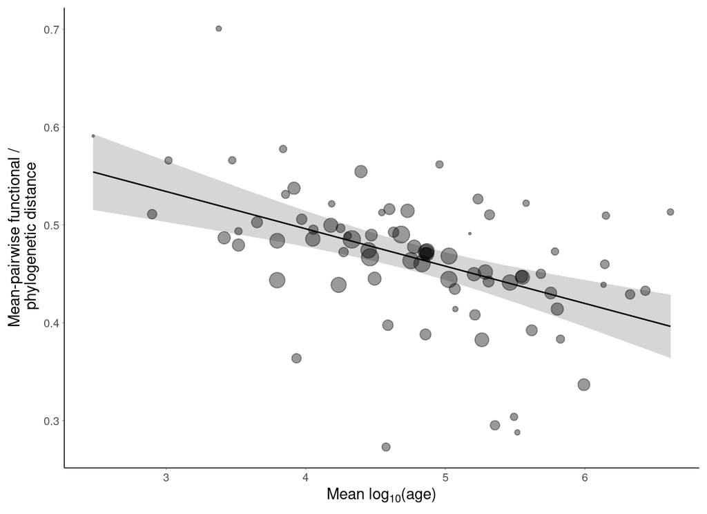

```r
pools.dat %>%
  ggplot(aes(age_mean,FPdist)) +
  stat_smooth(method="lm",colour="black",size=0.5) +
  geom_point(aes(size=pool_rich),shape=19,alpha=0.4) +
  scale_size(range = c(0.5,5.5))+
  labs(x=expression("Mean "*log[10]*"(age)"),
       y="Mean-pairwise functional /\n phylogenetic distance") +
  theme_classic() +
  theme(legend.position = "none",
        axis.title = element_text(size=11),
        axis.text = element_text(size=8),
        axis.line = element_line(size=0.3),
        axis.ticks = element_line(size=0.12),
        axis.ticks.length = unit(.05, "cm"))
```

```r
ggsave("output/figs/Fig3.pdf",height=8, width=11, units="cm")
```

## Plot species pool age or variance vs functional / phylogenetic diversity

```r
pan.lett <- data.frame(metric=c("Mean age","Variance age"),lab=c("(a)","(b)"))
```

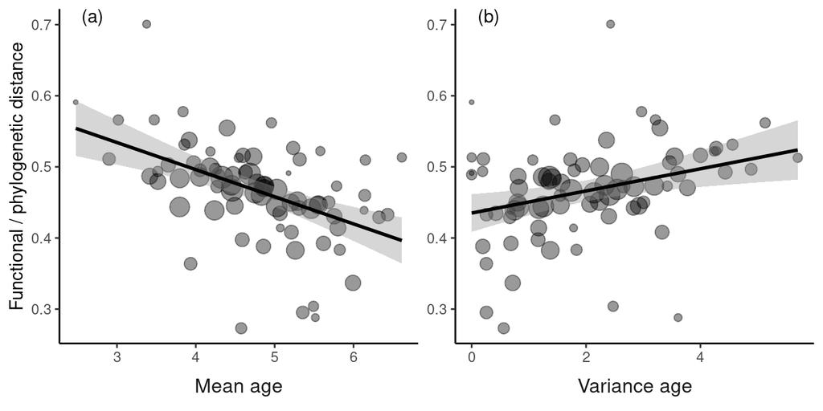

```r
pools.dat %>%
  transmute(richness=pool_rich,"Mean age"=age_mean,"Variance age"=age_var,FPdist=FPdist) %>%
  gather("metric","X",2:3) %>%
  ggplot(aes(X,FPdist)) +
  geom_point(aes(size=richness),shape=19,alpha=0.4) +
  stat_smooth(method="lm",colour="black") +
  facet_wrap(~metric,scales = "free", strip.position = "bottom") +
  labs(x=NULL, y="Functional / phylogenetic distance") +
  geom_text(data=pan.lett,aes(x=-Inf,y=Inf,label=lab),inherit.aes=F,hjust=-1,vjust=1) +
  theme_classic() +
  theme(strip.background = element_blank(),
        strip.placement = "outside",
        strip.text = element_text(size=12),
        legend.position = "none")
```

```r
ggsave("output/figs/Fig3_alt.pdf",height=4, width=8)
```

# Standardized effect size of mean pairwise distance (ses-mpd)

Load community data from saved phyloseq object

```r
phy <- readRDS("output/rds/phy.rds")
```

extract otu table and apply hellenger transform

```r
otu.tab <- otu_table(phy) %>% data.frame %>% decostand("hellinger")
```

Add a column for missing otus (never observed)

```r
#missing <- colnames(pools)[!(colnames(pools) %in% colnames(otu.tab))]
#for(i in 1:length(missing)){otu.tab[[missing[i]]] <- 0}
```

Filter pools to only include those remaining in the experiment (some lost due to poor sequencing)

```r
pools.remaining <- rownames(pools)[rownames(pools) %in% sample_data(phy)$poolID]
```

Calculate standardized effect size of mpd

```r
ses.func <- function(otu.tab,dist.mx){
  foreach(i=pools.remaining, .combine=rbind) %dopar% {
    samps <- sample_names(phy)[which(sample_data(phy)$poolID==i)]
    spp <- pools[i,] %>% unlist %>% .[.] %>% names
    ses.mpd(otu.tab[samps,spp],dist.mx[spp,spp],null.model="taxa.labels",abundance.weighted=T)
  }
}
ses.dat <- ses.func(otu.tab,FPdist)
```

test variation in ses.mpd

```r
ses.dat %<>% merge(data.frame(sample_data(phy)),by=0) %>% drop_na
(ses.mod <- lme(mpd.obs.z~pool_rich+age_var+age_mean,data=ses.dat, random=~1|poolID,method="REML")) %>% summary
```

```
## Linear mixed-effects model fit by REML
##  Data: ses.dat
##      AIC      BIC  logLik
##   233.28 254.8483 -110.64
##
## Random effects:
##  Formula: ~1 | poolID
##         (Intercept)  Residual
## StdDev:    0.719563 0.2131821
##
## Fixed effects: mpd.obs.z ~ pool_rich + age_var + age_mean
##                  Value Std.Error  DF   t-value p-value
## (Intercept)  2.0301288 0.5665795 199  3.583131  0.0004
## pool_rich    0.0035943 0.0115793  70  0.310404  0.7572
## age_var      0.0750529 0.0619523  70  1.211462  0.2298
## age_mean    -0.4369370 0.1026709  70 -4.255705  0.0001
##  Correlation:
##           (Intr) pl_rch age_vr
## pool_rich -0.378
## age_var   -0.364  0.146
## age_mean  -0.919  0.102  0.112
##
## Standardized Within-Group Residuals:
##          Min           Q1          Med           Q3          Max
## -3.224809065 -0.431543988 -0.003605758  0.447280235  3.406272850
##
## Number of Observations: 273
## Number of Groups: 74
```

summarize means of species pool reps for plotting trend line

```r
ses.dat.means <- ses.dat %>% group_by(poolID,age_mean,pool_rich,age_var) %>%
  summarize(mpd.obs.z=mean(mpd.obs.z))
```

Plot SES.mpd results

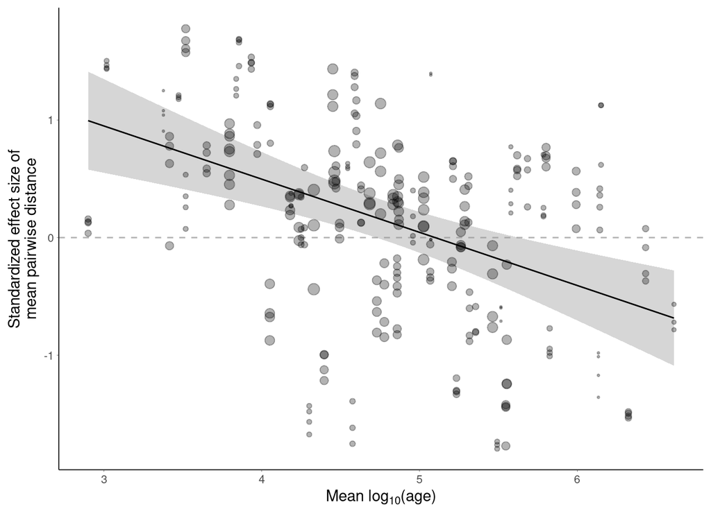

```r
ggplot(ses.dat, aes(x=age_mean,y=mpd.obs.z))+
  geom_hline(aes(yintercept=0),alpha=0.3,linetype="dashed",size=0.5)+
  xlim(c(min(ses.dat$age_mean),max(ses.dat$age_mean)))+
  stat_smooth(data=ses.dat.means,method="lm",colour="black",size=0.5) +
  geom_point(aes(size=pool_rich),shape=19,alpha=0.3) +
  scale_size(range = c(0.5,3.5))+
  labs(y="Standardized effect size of\nmean pairwise distance",
       x=expression("Mean "*log[10]*"(age)")) +
  theme_classic() +
  theme(legend.position = "none",
        axis.title = element_text(size=11),
        axis.text = element_text(size=8),
        axis.line = element_line(size=0.3),
        axis.ticks = element_line(size=0.12),
        axis.ticks.length = unit(.05, "cm"))
```

```r
ggsave("output/figs/Fig4.pdf",height=8, width=11, units="cm")
```